# Anleitung Coding mit RQDA

David Presberger

17 Juni 2017

Liebe Gruppenmitglieder, hier die Anleitung, wie ihr in RQDA coded.

## Arbeitsaufwand und Ziel

**Arbeitsaufwand**: max. 20 Minuten **Ziel**: Jeder hat zu einer Variable die Aussagen in allen Interviews

## 1. R installieren

**!!Wichtig!!**: Installiere zuerst die **!aktuellste!** Version von R (3.4.0)

*(Wer schon R hat (aber ältere Version), trotzdem installieren - R can man nicht updaten)*

Falls **Windows**, dieser Link: https://cran.r-project.org/bin/windows/base/

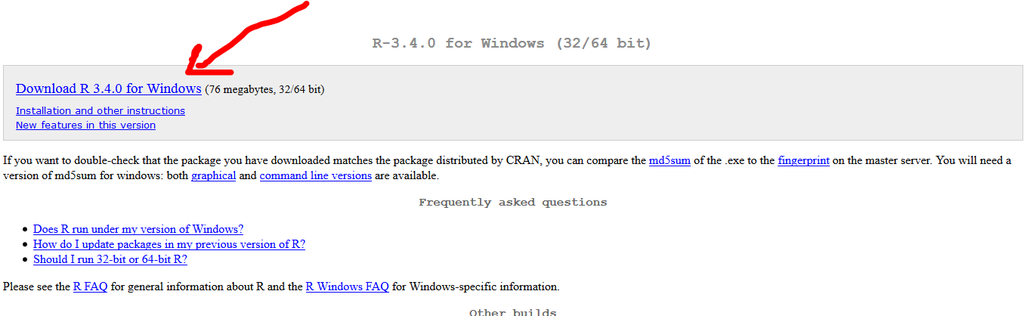

Falls **Mac**, dieser Link: https://cran.r-project.org/bin/macosx/

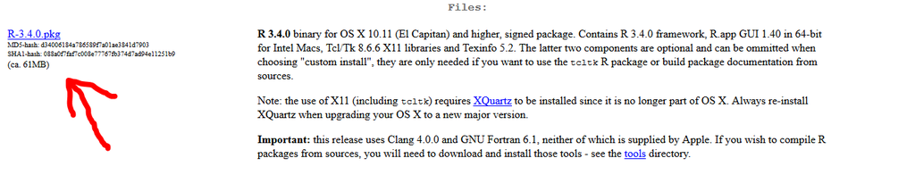

*Jetzt das Programm installieren und starten*

## RQDA installieren

In die Eingabezeile:

[figure not shown]

Folgendes eingeben:

```r
install.packages("RQDA")
```

**!!WICHTIG!!**: Wenn nachgefragt wird, ob **RGtk2** auch istalliert werden soll, **Ja** drücken. **Auch andere Packages installieren, falls R danach fragt!!**

Wenn erfolgreich installiert, folgendes eingeben:

```r
library(RQDA)
```

Es öffnet sich nach einiger Zeit eine Benutzeroberfläche. *Dies ist RQDA*

## Mit RQDA Codieren

**Nun musst du das Projekt öffnen, das ich dir geschickt habe.**

Klicke hierfür auf **“Open Project”** und wähle die “.rqda” Datei aus.

**In dem Projekt habe ich bereits alle notwendigen Codes für die Variablen eingefügt.**

Jetzt klickst du auf **“Files”** und dann Doppelklick auf das Interview, das in deinem Projekt aufgeführt ist. Nun erscheint wie von Zauberhand ein Fenster mit dem Interviewtranskript.

[figure not shown]

**Wichtig: Das Fenster mit dem Transkript muss nicht geschlossen werden!**

**Um zu codieren, wähle im Reiter “Codes” aus. Klicke nun auf den Code mit dem du die Textstellen codifizieren möchtest (hier Integration). Gehe jetzt wieder in dein Fenster mit dem Transkript und markiere die zu codierende Stelle. Klicke nun im anderen Fenster auf “Mark”. Und fertig ist’s!**

[figure not shown]

Bitte codiert nur die Antworten des Interviewpartners und nicht die Fragen (wie hier im Beispiel).

**ACHTUNG!: Es kommt die Fehlermeldung “Fail to write to database” - das lässt sich nicht ändern, wer wissen möchte was da falsch läuft kann gerne mal dem Entwickler eine Mail schreiben. Der Fehler wirkt sich aber nicht auf die Speicherung aus.**

## Nächster Schritt

**Schicke mir, wenn du fertig bist deine .rqda Datei per Mail zurück. Ich werde dann alle Interviews zusammenfügen**

## Anmerkung

**ACHTUNG!: Es gibt keine Rückgängigmachungs-Funktion, jede Veränderung wird gespeichert.**

**ACHTUNG!!: ÄNDERE NICHT DEN NAMEN DER INTERVIEW FILES!**